# Entailment Free-Choice (Study 1)

Bartosz

# Overview

- Task: judge whether a Conclusion follows from a Premise (keys: `B` = follows, `N` = does not follow).
- Design: 8 practice trials (controls with feedback) + 96 experimental trials (48 critical modal/want; 48 control fillers; no feedback).
- Stimuli metadata fields in `results.csv`: `domain` (`modal`, `want`, `control`), `pair_type` (e.g., `allowed_and`, `want_single`), `conclusion_form` (`A`, `B`, `AND`, or empty for controls), and validity (`STIMULUS_VALID`: `Y`, `N`, or `?` for unknown/critical).

# Data Preparation

Data summary: Data include 40 participant(s) with 320 practice trials and 3840 experimental trials. Session counts: practice = 320, experimental = 3840. Responses recoded to binary (B=1, N=0) and accuracy computed where validity was known.

# Stimuli inventory (paper methods)

```
## $stimuli_inventory_text
## Unique stimuli counts: practice = 8 item(s), experimental = 96 item(s).
##
## $stimuli_counts_by_domain
## # A tibble: 3 × 2
##   domain  `N items`
##   <fct>       <int>
## 1 control        48
## 2 modal          24
## 3 want           24
##
## $stimuli_counts_practice
## # A tibble: 8 × 3
##   pair_type      STIMULUS_VALID `N items`
##   <fct>          <chr>              <int>
## 1 quantifier     N                      1
## 2 quantifier     Y                      1
## 3 conjunction    N                      1
## 4 conjunction    Y                      1
## 5 presupposition N                      1
## 6 presupposition Y                      1
## 7 conditional    N                      1
## 8 conditional    Y                      1
##
## $stimuli_counts_controls
## # A tibble: 8 × 3
##   pair_type      STIMULUS_VALID `N items`
##   <fct>          <chr>              <int>
## 1 quantifier     N                      6
## 2 quantifier     Y                      6
## 3 conjunction    N                      6
## 4 conjunction    Y                      6
## 5 presupposition N                      6
## 6 presupposition Y                      6
## 7 conditional    N                      6
## 8 conditional    Y                      6
##
## $stimuli_counts_critical
## # A tibble: 17 × 4
##    domain pair_type        conclusion_form `N items`
##    <fct>  <fct>            <fct>               <int>
##  1 modal  must_and         AND                     4
##  2 modal  allowed_single   B                       2
##  3 modal  allowed_single   A                       2
##  4 modal  must_single      B                       2
##  5 modal  must_single      A                       2
##  6 modal  allowed_and      AND                     4
##  7 modal  all_and          AND                     4
##  8 modal  all_single       B                       2
##  9 modal  all_single       A                       2
## 10 want   want_mind_and    AND                     4
## 11 want   atleast_single_b B                       4
## 12 want   want_and         AND                     4
## 13 want   atleast_single_a A                       4
## 14 want   want_mind_single B                       2
## 15 want   want_mind_single A                       2
## 16 want   want_single      B                       2
## 17 want   want_single      A                       2
```

Unique stimuli counts: practice = 8 item(s), experimental = 96 item(s).

Experimental items by domain (unique stimuli):

| domain | N items |
| --- | --- |
| control | 48 |
| modal | 24 |
| want | 24 |

Practice items (unique stimuli):

| pair_type | STIMULUS_VALID | N items |
| --- | --- | --- |
| quantifier | N | 1 |
| quantifier | Y | 1 |
| conjunction | N | 1 |
| conjunction | Y | 1 |
| presupposition | N | 1 |
| presupposition | Y | 1 |
| conditional | N | 1 |
| conditional | Y | 1 |

Experimental control items (unique stimuli):

| pair_type | STIMULUS_VALID | N items |
| --- | --- | --- |
| quantifier | N | 6 |
| quantifier | Y | 6 |
| conjunction | N | 6 |
| conjunction | Y | 6 |
| presupposition | N | 6 |
| presupposition | Y | 6 |
| conditional | N | 6 |
| conditional | Y | 6 |

Experimental critical items (unique stimuli):

| domain | pair_type | conclusion_form | N items |
| --- | --- | --- | --- |
| modal | must_and | AND | 4 |
| modal | allowed_single | B | 2 |
| modal | allowed_single | A | 2 |
| modal | must_single | B | 2 |
| modal | must_single | A | 2 |
| modal | allowed_and | AND | 4 |
| modal | all_and | AND | 4 |
| modal | all_single | B | 2 |
| modal | all_single | A | 2 |
| want | want_mind_and | AND | 4 |
| want | atleast_single_b | B | 4 |
| want | want_and | AND | 4 |
| want | atleast_single_a | A | 4 |
| want | want_mind_single | B | 2 |
| want | want_mind_single | A | 2 |
| want | want_single | B | 2 |
| want | want_single | A | 2 |

# Manipulation Checks

Manipulation check: Participants contributed between 96 and 96 experimental trials (mean = 96). Trial counts cover all domains and pair types.

# Demographics

```
## $demog_summary
## # A tibble: 1 × 6
##   `Matched participants` `Participants in data` `Mean age` `SD age` `Min age`
##                    <int>                  <int>      <dbl>    <dbl>     <dbl>
## 1                     40                     40       47.1     13.7        26
## # ℹ 1 more variable: `Max age` <dbl>
##
## $missing_demog
## character(0)
```

Matched demographics summary:

| Matched participants | Participants in data | Mean age | SD age | Min age | Max age |
| --- | --- | --- | --- | --- | --- |
| 40 | 40 | 47.075 | 13.72885 | 26 | 75 |

Sex distribution:

| Sex | Count | Percent |
| --- | --- | --- |
| Female | 24 | 60% |
| Male | 16 | 40% |

Ethnicity distribution:

| Ethnicity | Count | Percent |
| --- | --- | --- |
| Asian | 1 | 2.5% |
| Black | 4 | 10.0% |
| Mixed | 2 | 5.0% |
| Other | 1 | 2.5% |
| White | 32 | 80.0% |

Country of residence distribution:

| Country of residence | Count | Percent |
| --- | --- | --- |
| United Kingdom | 30 | 75% |
| United States | 10 | 25% |

Unmatched participant IDs (if any):

All participants with data matched to Prolific demographics.

# Response Patterns (Experimental Trials)

### Proportion of “Follows” Responses (by grouping)

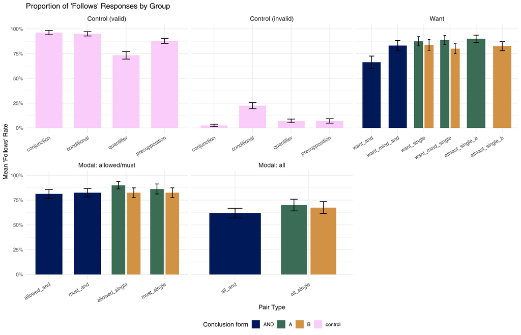

Underlying descriptives:

| Group | Pair type | Conclusion form | Mean follows | SE | n |
| --- | --- | --- | --- | --- | --- |
| Control (valid) | conjunction | control | 96.2% | 0.022 | 40 |
| Control (valid) | conditional | control | 95.0% | 0.022 | 40 |
| Control (valid) | quantifier | control | 73.3% | 0.038 | 40 |
| Control (valid) | presupposition | control | 87.9% | 0.025 | 40 |
| Control (invalid) | conjunction | control | 2.5% | 0.013 | 40 |
| Control (invalid) | conditional | control | 22.5% | 0.031 | 40 |
| Control (invalid) | quantifier | control | 7.1% | 0.019 | 40 |
| Control (invalid) | presupposition | control | 7.1% | 0.022 | 40 |
| Want | want_and | AND | 66.2% | 0.063 | 40 |
| Want | want_mind_and | AND | 83.1% | 0.052 | 40 |
| Want | want_single | A | 87.5% | 0.047 | 40 |
| Want | want_single | B | 83.8% | 0.055 | 40 |
| Want | want_mind_single | A | 88.7% | 0.046 | 40 |
| Want | want_mind_single | B | 80.0% | 0.050 | 40 |
| Want | atleast_single_a | A | 90.0% | 0.037 | 40 |
| Want | atleast_single_b | B | 82.5% | 0.046 | 40 |
| Modal: allowed/must | allowed_and | AND | 81.2% | 0.045 | 40 |
| Modal: allowed/must | must_and | AND | 82.5% | 0.043 | 40 |
| Modal: allowed/must | allowed_single | A | 90.0% | 0.037 | 40 |
| Modal: allowed/must | allowed_single | B | 82.5% | 0.049 | 40 |
| Modal: allowed/must | must_single | A | 86.2% | 0.051 | 40 |
| Modal: allowed/must | must_single | B | 82.5% | 0.049 | 40 |
| Modal: all | all_and | AND | 61.9% | 0.049 | 40 |
| Modal: all | all_single | A | 70.0% | 0.059 | 40 |
| Modal: all | all_single | B | 67.5% | 0.061 | 40 |

## Paper-ready summary: want_single vs invalid controls

Primary contrast for the paper: the extent to which participants accept the FC-style inference from a *want + disjunction* premise to a *single-disjunct want* conclusion (`want_single`), compared to their tendency to accept clearly invalid control inferences.

Primary descriptives:

| Group | Mean follows | SD | 95% CI | N participants |
| --- | --- | --- | --- | --- |
| Control: invalid | 9.8% | 10.5% | [6.4%, 13.2%] | 40 |
| Want: want_single | 85.6% | 30.4% | [75.9%, 95.4%] | 40 |

Primary comparison test:

Paired t-test on participant means: t(39) = 14.82, p = <0.001, dz = 2.34.

### Primary comparison (model-based): want_single vs invalid controls

In addition to participant-mean descriptives, we estimate the same contrast using a mixed-effects logistic regression on trial-level responses.

Model-based estimated “follows” rates:

| paper_group | prob | SE | df | asymp.LCL | asymp.UCL |
| --- | --- | --- | --- | --- | --- |
| Control: invalid | 0.03650541 | 0.01348729 | Inf | 0.01755559 | 0.07436176 |
| Want: want_single | 0.91080635 | 0.05731949 | Inf | 0.71922519 | 0.97602366 |

Model-based comparison:

Mixed-effects logistic regression (random intercepts for participant and item): OR = 269.52, 95% CI [58.87, 1233.88], z = 7.21, p = <0.001.

### Paper-ready summary: all conditions (collapsed over A/B where applicable)

The table below collapses across `A`/`B` conclusion variants for single-disjunct conditions.

Condition-level descriptives (participant means):

| Condition | Mean follows | SD | 95% CI | N participants |
| --- | --- | --- | --- | --- |
| Control: invalid | 9.8% | 10.5% | [6.4%, 13.2%] | 40 |
| Control: valid | 88.1% | 13.2% | [83.9%, 92.4%] | 40 |
| Modal: all_and | 61.9% | 31.0% | [52.0%, 71.8%] | 40 |
| Modal: all_single | 68.8% | 34.8% | [57.6%, 79.9%] | 40 |
| Modal: allowed_and | 81.2% | 28.7% | [72.1%, 90.4%] | 40 |
| Modal: allowed_single | 86.2% | 25.3% | [78.2%, 94.3%] | 40 |
| Modal: must_and | 82.5% | 27.3% | [73.8%, 91.2%] | 40 |
| Modal: must_single | 84.4% | 28.7% | [75.2%, 93.6%] | 40 |
| Want: atleast_single_a | 90.0% | 23.2% | [82.6%, 97.4%] | 40 |
| Want: atleast_single_b | 82.5% | 29.0% | [73.2%, 91.8%] | 40 |
| Want: want_and | 66.2% | 39.9% | [53.5%, 79.0%] | 40 |
| Want: want_mind_and | 83.1% | 32.7% | [72.7%, 93.6%] | 40 |
| Want: want_mind_single | 84.4% | 27.0% | [75.8%, 93.0%] | 40 |
| Want: want_single | 85.6% | 30.4% | [75.9%, 95.4%] | 40 |

## Additional comparisons: benchmark modal FC vs want FC

The main text currently reports the primary contrast (`want_single` vs invalid controls). For interpretability, it is also useful to compare FC endorsement rates in *benchmark permission modals* (allowed) to FC endorsement rates under *want*.

We focus on the four directly comparable conditions:

- **Modal (allowed):** `allowed_single` and `allowed_and`
- **Want:** `want_single` and `want_and`

### Descriptives (participant means)

| Domain | Conclusion | Mean follows | SD | 95% CI | N participants |
| --- | --- | --- | --- | --- | --- |
| Modal: allowed | single | 86.2% | 25.3% | [78.2%, 94.3%] | 40 |
| Modal: allowed | and | 81.2% | 28.7% | [72.1%, 90.4%] | 40 |
| Want | single | 85.6% | 30.4% | [75.9%, 95.4%] | 40 |
| Want | and | 66.2% | 39.9% | [53.5%, 79.0%] | 40 |

### Model-based comparison (mixed-effects logistic regression)

Model-based predicted “follows” rates:

| Domain | Conclusion | Predicted follows | 95% CI (low) | 95% CI (high) | z | p |
| --- | --- | --- | --- | --- | --- | --- |
| Modal: allowed | single | 94.2% | 87.2% | 97.5% | 6.303762 | 0.0000000002905071 |
| Want | single | 93.8% | 86.5% | 97.3% | 6.195353 | 0.0000000005815448 |
| Modal: allowed | and | 90.7% | 81.1% | 95.7% | 5.441125 | 0.0000000529450334 |
| Want | and | 75.5% | 59.2% | 86.7% | 2.937296 | 0.0033108814643403 |

Domain contrasts (Want vs Modal: allowed), separately for `single` vs `and` conclusions:

| Conclusion type | Contrast | OR (95% CI) | z | p |
| --- | --- | --- | --- | --- |
| single | Modal: allowed - Want | 1.07 [0.52, 2.22] | 0.19 | 0.853 |
| and | Modal: allowed - Want | 3.17 [1.69, 5.96] | 3.59 | <0.001 |

Conclusion-type contrasts (`and` vs `single`), separately within each domain:

| Domain | Contrast | OR (95% CI) | z | p |
| --- | --- | --- | --- | --- |
| Modal: allowed | single - and | 1.65 [0.82, 3.32] | 1.41 | 0.16 |
| Want | single - and | 4.89 [2.5, 9.57] | 4.63 | <0.001 |

### Controls: Accuracy (Known Validity Only)

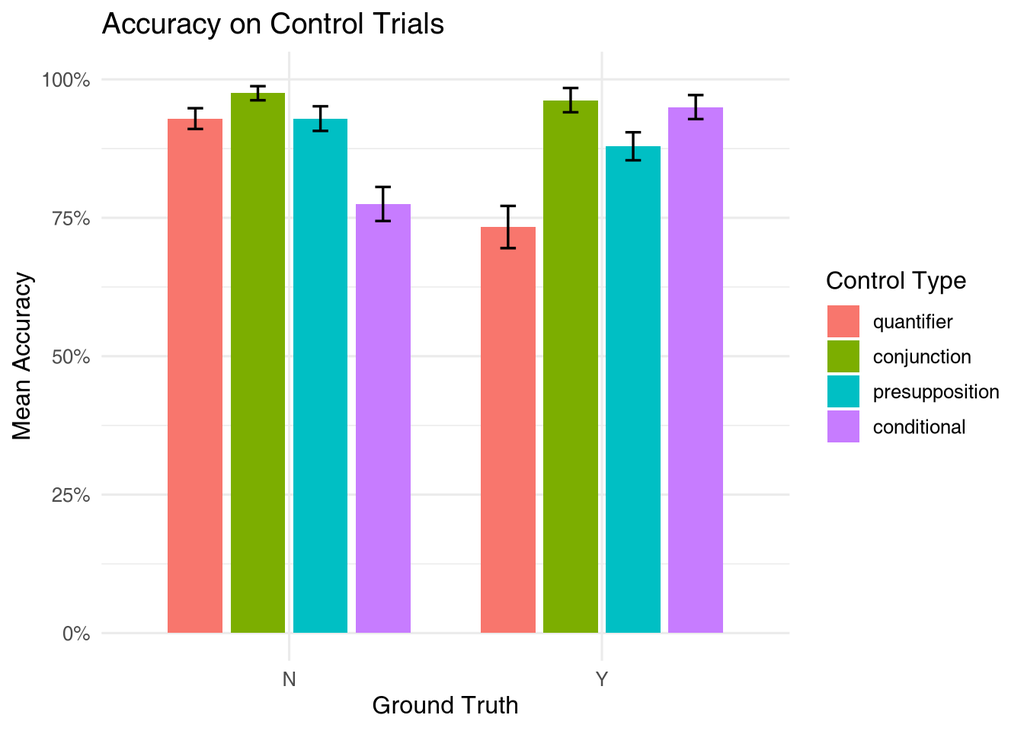

# Response Time (Experimental Trials)

Trim obvious outliers (e.g., <200 ms or >20 s) and reuse the grouping from above.

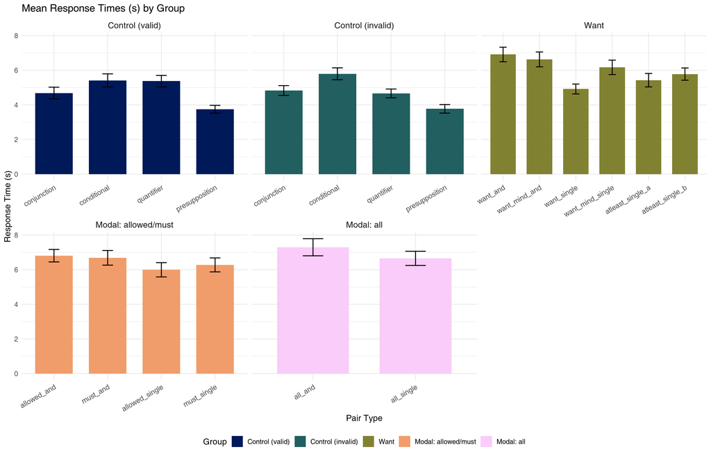

Underlying descriptives:

| Group | Pair type | Mean RT (s) | SE | n |
| --- | --- | --- | --- | --- |
| Control (valid) | conjunction | 4.68 | 0.34 | 40 |
| Control (valid) | conditional | 5.42 | 0.38 | 40 |
| Control (valid) | quantifier | 5.37 | 0.33 | 40 |
| Control (valid) | presupposition | 3.75 | 0.23 | 40 |
| Control (invalid) | conjunction | 4.83 | 0.28 | 40 |
| Control (invalid) | conditional | 5.80 | 0.34 | 40 |
| Control (invalid) | quantifier | 4.66 | 0.25 | 40 |
| Control (invalid) | presupposition | 3.77 | 0.25 | 40 |
| Want | want_and | 6.91 | 0.42 | 40 |
| Want | want_mind_and | 6.63 | 0.43 | 40 |
| Want | want_single | 4.92 | 0.29 | 40 |
| Want | want_mind_single | 6.17 | 0.42 | 40 |
| Want | atleast_single_a | 5.43 | 0.39 | 40 |
| Want | atleast_single_b | 5.78 | 0.35 | 40 |
| Modal: allowed/must | allowed_and | 6.81 | 0.36 | 40 |
| Modal: allowed/must | must_and | 6.69 | 0.42 | 40 |
| Modal: allowed/must | allowed_single | 5.99 | 0.41 | 40 |
| Modal: allowed/must | must_single | 6.28 | 0.40 | 40 |
| Modal: all | all_and | 7.30 | 0.49 | 40 |
| Modal: all | all_single | 6.65 | 0.41 | 40 |

# Modeling

## Proportion of “Follows” Responses (by grouping)

|  | resp |  |  |
| --- | --- | --- | --- |
| Predictors | Odds Ratios | CI | p |
| (Intercept) | 6.25 | 3.65 – 10.72 | **<0.001** |
| domain [want] | 1.31 | 0.69 – 2.50 | 0.405 |
| pair type [want_mind_and] | 0.80 | 0.42 – 1.53 | 0.502 |
| pair type [atleast_single_b] | 0.76 | 0.40 – 1.45 | 0.405 |
| pair type [allowed_single] | 1.39 | 0.73 – 2.67 | 0.315 |
| pair type [want_and] | 0.27 | 0.15 – 0.48 | **<0.001** |
| pair type [must_single] | 1.17 | 0.62 – 2.21 | 0.622 |
| pair type [atleast_single_a] | 1.60 | 0.78 – 3.29 | 0.198 |
| pair type [want_mind_single] | 0.89 | 0.46 – 1.72 | 0.733 |
| pair type [allowed_and] | 0.91 | 0.49 – 1.67 | 0.750 |
| pair type [all_and] | 0.28 | 0.16 – 0.49 | **<0.001** |
| pair type [all_single] | 0.40 | 0.23 – 0.71 | **0.002** |
| Random Effects |  |  |  |
| σ<sup>2</sup> | 3.29 |  |  |
| τ<sub>00</sub> <sub>item</sub> | 0.00 |  |  |
| τ<sub>00</sub> <sub>participant</sub> | 0.97 |  |  |
| N <sub>participant</sub> | 40 |  |  |
| N <sub>item</sub> | 48 |  |  |
| Observations | 1920 |  |  |
| Marginal R<sup>2</sup> / Conditional R<sup>2</sup> | 0.095 / NA |  |  |

| domain | term | contrast | null.value | odds.ratio | std.error | df | null | statistic | adj.p.value |
| --- | --- | --- | --- | --- | --- | --- | --- | --- | --- |
| modal | pair_type | must_and / allowed_single | 0 | 0.717 | 0.237 | Inf | 1 | -1.006 | 1.000 |
| modal | pair_type | must_and / must_single | 0 | 0.853 | 0.275 | Inf | 1 | -0.493 | 1.000 |
| modal | pair_type | must_and / allowed_and | 0 | 1.104 | 0.344 | Inf | 1 | 0.318 | 1.000 |
| modal | pair_type | must_and / all_and | 0 | 3.577 | 1.025 | Inf | 1 | 4.451 | 0.003 |
| modal | pair_type | must_and / all_single | 0 | 2.480 | 0.721 | Inf | 1 | 3.122 | 0.297 |
| modal | pair_type | allowed_single / must_single | 0 | 1.190 | 0.401 | Inf | 1 | 0.515 | 1.000 |
| modal | pair_type | allowed_single / allowed_and | 0 | 1.540 | 0.504 | Inf | 1 | 1.320 | 1.000 |
| modal | pair_type | allowed_single / all_and | 0 | 4.990 | 1.516 | Inf | 1 | 5.290 | < 0.001 |
| modal | pair_type | allowed_single / all_single | 0 | 3.459 | 1.065 | Inf | 1 | 4.030 | 0.018 |
| modal | pair_type | must_single / allowed_and | 0 | 1.294 | 0.413 | Inf | 1 | 0.810 | 1.000 |
| modal | pair_type | must_single / all_and | 0 | 4.193 | 1.234 | Inf | 1 | 4.872 | < 0.001 |
| modal | pair_type | must_single / all_single | 0 | 2.907 | 0.868 | Inf | 1 | 3.575 | 0.088 |
| modal | pair_type | allowed_and / all_and | 0 | 3.240 | 0.914 | Inf | 1 | 4.169 | 0.010 |
| modal | pair_type | allowed_and / all_single | 0 | 2.246 | 0.644 | Inf | 1 | 2.823 | 0.526 |
| modal | pair_type | all_and / all_single | 0 | 0.693 | 0.178 | Inf | 1 | -1.427 | 1.000 |
| want | pair_type | want_mind_and / atleast_single_b | 0 | 1.053 | 0.335 | Inf | 1 | 0.162 | 1.000 |
| want | pair_type | want_mind_and / want_and | 0 | 2.995 | 0.872 | Inf | 1 | 3.766 | 0.047 |
| want | pair_type | want_mind_and / atleast_single_a | 0 | 0.500 | 0.179 | Inf | 1 | -1.937 | 0.986 |
| want | pair_type | want_mind_and / want_mind_single | 0 | 0.898 | 0.291 | Inf | 1 | -0.331 | 1.000 |
| want | pair_type | want_mind_and / want_single | 0 | 0.801 | 0.264 | Inf | 1 | -0.671 | 1.000 |
| want | pair_type | atleast_single_b / want_and | 0 | 2.845 | 0.822 | Inf | 1 | 3.619 | 0.077 |
| want | pair_type | atleast_single_b / atleast_single_a | 0 | 0.475 | 0.169 | Inf | 1 | -2.092 | 0.963 |
| want | pair_type | atleast_single_b / want_mind_single | 0 | 0.853 | 0.275 | Inf | 1 | -0.493 | 1.000 |
| want | pair_type | atleast_single_b / want_single | 0 | 0.761 | 0.250 | Inf | 1 | -0.832 | 1.000 |
| want | pair_type | want_and / atleast_single_a | 0 | 0.167 | 0.056 | Inf | 1 | -5.364 | < 0.001 |
| want | pair_type | want_and / want_mind_single | 0 | 0.300 | 0.089 | Inf | 1 | -4.061 | 0.016 |
| want | pair_type | want_and / want_single | 0 | 0.268 | 0.081 | Inf | 1 | -4.356 | 0.005 |
| want | pair_type | atleast_single_a / want_mind_single | 0 | 1.797 | 0.651 | Inf | 1 | 1.619 | 0.999 |
| want | pair_type | atleast_single_a / want_single | 0 | 1.604 | 0.588 | Inf | 1 | 1.287 | 1.000 |
| want | pair_type | want_mind_single / want_single | 0 | 0.892 | 0.298 | Inf | 1 | -0.341 | 1.000 |

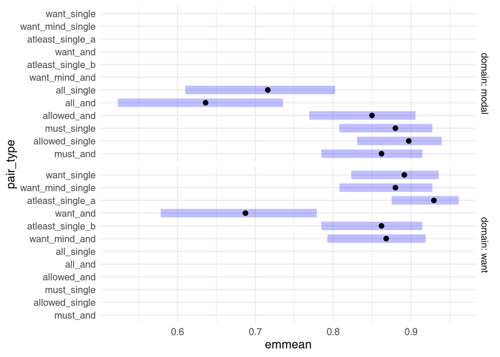

## Response Time (Experimental Trials)

|  | rt |  |  |
| --- | --- | --- | --- |
| Predictors | Estimates | CI | p |
| (Intercept) | 7298.60 | 5645.30 – 8951.90 | **<0.001** |
| domain [want] | -1746.51 | -3660.58 – 167.57 | 0.074 |
| pair type [want_mind_and] | 1625.59 | -288.48 – 3539.67 | 0.096 |
| pair type [atleast_single_b] | 1058.72 | -855.36 – 2972.80 | 0.278 |
| pair type [allowed_single] | 26.69 | -1887.39 – 1940.77 | 0.978 |
| pair type [want_and] | 2097.80 | 183.72 – 4011.88 | **0.032** |
| pair type [must_single] | -181.76 | -2095.84 – 1732.32 | 0.852 |
| pair type [atleast_single_a] | 781.61 | -1132.47 – 2695.69 | 0.423 |
| pair type [want_mind_single] | 2200.81 | 286.73 – 4114.88 | **0.024** |
| pair type [allowed_and] | 1601.95 | -312.13 – 3516.03 | 0.101 |
| pair type [all_and] | 1846.66 | -67.42 – 3760.73 | 0.059 |
| pair type [all_single] | 283.14 | -1630.93 – 2197.22 | 0.772 |
| Random Effects |  |  |  |
| σ<sup>2</sup> | 66239983.03 |  |  |
| τ<sub>00</sub> <sub>item</sub> | 249026.60 |  |  |
| τ<sub>00</sub> <sub>participant</sub> | 9375709.68 |  |  |
| ICC | 0.13 |  |  |
| N <sub>participant</sub> | 40 |  |  |
| N <sub>item</sub> | 48 |  |  |
| Observations | 1920 |  |  |
| Marginal R<sup>2</sup> / Conditional R<sup>2</sup> | 0.012 / 0.137 |  |  |

| domain | term | contrast | null.value | estimate | std.error | df | statistic | adj.p.value |
| --- | --- | --- | --- | --- | --- | --- | --- | --- |
| modal | pair_type | must_and - allowed_single | 0 | -26.687 | 975.968 | 36 | -0.027 | 1.000 |
| modal | pair_type | must_and - must_single | 0 | 181.763 | 975.968 | 36 | 0.186 | 1.000 |
| modal | pair_type | must_and - allowed_and | 0 | -1,601.950 | 975.968 | 36 | -1.641 | 0.997 |
| modal | pair_type | must_and - all_and | 0 | -1,846.656 | 975.968 | 36 | -1.892 | 0.979 |
| modal | pair_type | must_and - all_single | 0 | -283.144 | 975.968 | 36 | -0.290 | 1.000 |
| modal | pair_type | allowed_single - must_single | 0 | 208.450 | 975.968 | 36 | 0.214 | 1.000 |
| modal | pair_type | allowed_single - allowed_and | 0 | -1,575.263 | 975.968 | 36 | -1.614 | 0.997 |
| modal | pair_type | allowed_single - all_and | 0 | -1,819.969 | 975.968 | 36 | -1.865 | 0.982 |
| modal | pair_type | allowed_single - all_single | 0 | -256.456 | 975.968 | 36 | -0.263 | 1.000 |
| modal | pair_type | must_single - allowed_and | 0 | -1,783.713 | 975.968 | 36 | -1.828 | 0.986 |
| modal | pair_type | must_single - all_and | 0 | -2,028.419 | 975.968 | 36 | -2.078 | 0.944 |
| modal | pair_type | must_single - all_single | 0 | -464.906 | 975.968 | 36 | -0.476 | 1.000 |
| modal | pair_type | allowed_and - all_and | 0 | -244.706 | 975.968 | 36 | -0.251 | 1.000 |
| modal | pair_type | allowed_and - all_single | 0 | 1,318.806 | 975.968 | 36 | 1.351 | 1.000 |
| modal | pair_type | all_and - all_single | 0 | 1,563.512 | 975.968 | 36 | 1.602 | 0.998 |
| want | pair_type | want_mind_and - atleast_single_b | 0 | 566.875 | 975.968 | 36 | 0.581 | 1.000 |
| want | pair_type | want_mind_and - want_and | 0 | -472.206 | 975.968 | 36 | -0.484 | 1.000 |
| want | pair_type | want_mind_and - atleast_single_a | 0 | 843.981 | 975.968 | 36 | 0.865 | 1.000 |
| want | pair_type | want_mind_and - want_mind_single | 0 | -575.212 | 975.968 | 36 | -0.589 | 1.000 |
| want | pair_type | want_mind_and - want_single | 0 | 1,625.594 | 975.968 | 36 | 1.666 | 0.996 |
| want | pair_type | atleast_single_b - want_and | 0 | -1,039.081 | 975.968 | 36 | -1.065 | 1.000 |
| want | pair_type | atleast_single_b - atleast_single_a | 0 | 277.106 | 975.968 | 36 | 0.284 | 1.000 |
| want | pair_type | atleast_single_b - want_mind_single | 0 | -1,142.087 | 975.968 | 36 | -1.170 | 1.000 |
| want | pair_type | atleast_single_b - want_single | 0 | 1,058.719 | 975.968 | 36 | 1.085 | 1.000 |
| want | pair_type | want_and - atleast_single_a | 0 | 1,316.187 | 975.968 | 36 | 1.349 | 1.000 |
| want | pair_type | want_and - want_mind_single | 0 | -103.006 | 975.968 | 36 | -0.106 | 1.000 |
| want | pair_type | want_and - want_single | 0 | 2,097.800 | 975.968 | 36 | 2.149 | 0.923 |
| want | pair_type | atleast_single_a - want_mind_single | 0 | -1,419.194 | 975.968 | 36 | -1.454 | 0.999 |
| want | pair_type | atleast_single_a - want_single | 0 | 781.612 | 975.968 | 36 | 0.801 | 1.000 |
| want | pair_type | want_mind_single - want_single | 0 | 2,200.806 | 975.968 | 36 | 2.255 | 0.884 |

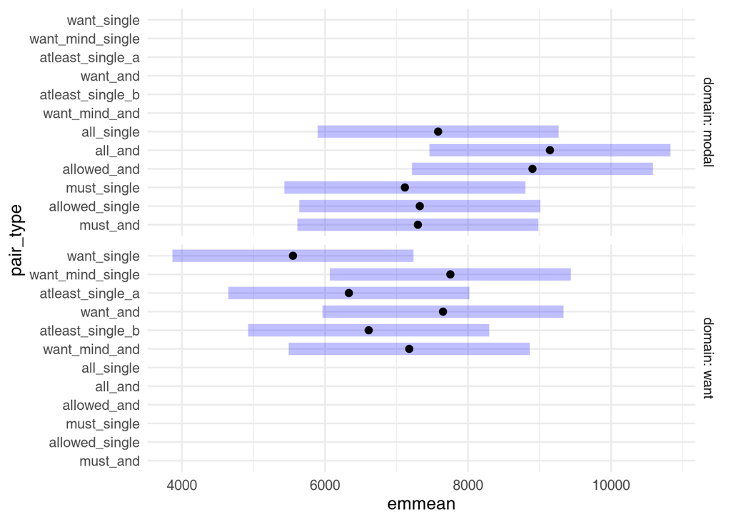

# Per-Item “Follows” Rates

| Item | Premise | Conclusion | Domain | Condition | Conclusion_form | N responses | Follows % |
| --- | --- | --- | --- | --- | --- | --- | --- |
| M00 | Morgan is allowed to garnish the plates or bake the rolls. | Morgan is allowed to garnish the plates and is allowed to bake the rolls. | modal | allowed_and | AND | 40 | 80.0% |
| M01 | Kendall has permission to print the travel itinerary or to check the boarding times. | Kendall has permission to print the travel itinerary and has permission to check the boarding times. | modal | allowed_and | AND | 40 | 85.0% |
| M02 | Kennedy is free to harvest the cucumbers or compost the clippings. | Kennedy is free to harvest the cucumbers and is free to compost the clippings. | modal | allowed_and | AND | 40 | 82.5% |
| M03 | Drew is cleared to repair the loose hinge or sweep the front porch. | Drew is cleared to repair the loose hinge and cleared to sweep the front porch. | modal | allowed_and | AND | 40 | 77.5% |
| M04 | Jules is allowed to dim the room lights or collect the RSVPs. | Jules is allowed to dim the room lights. | modal | allowed_single | A | 40 | 90.0% |
| M05 | Devin has permission to photograph the sculpture garden or to adjust the white balance. | Devin has permission to adjust the white balance. | modal | allowed_single | B | 40 | 82.5% |
| M06 | Parker is free to renew the passport or arrange the airport ride. | Parker is free to renew the passport. | modal | allowed_single | A | 40 | 90.0% |
| M07 | Sage is cleared to paint the background or cut the stencil. | Sage is cleared to cut the stencil. | modal | allowed_single | B | 40 | 82.5% |
| M08 | Eden should clean the air filter or replace the lightbulb. | Eden may clean the air filter, and may replace the lightbulb. | modal | must_and | AND | 40 | 80.0% |
| M09 | Blair is supposed to frame the illustration or varnish the surface. | Blair is allowed to frame the illustration and is allowed to varnish the surface. | modal | must_and | AND | 40 | 82.5% |
| M10 | Riley is expected to boil the pasta or chop the vegetables. | Riley is free to boil the pasta and is free to chop the vegetables. | modal | must_and | AND | 40 | 80.0% |
| M11 | Cameron is required to pack the carry-on bag or book the train tickets. | Cameron is allowed to pack the carry-on bag and is allowed to book the train tickets. | modal | must_and | AND | 40 | 87.5% |
| M12 | Tegan should sew the fabric border or glue the pieces. | Tegan may sew the fabric border. | modal | must_single | A | 40 | 87.5% |
| M13 | Logan is supposed to clean the exercise gear or time the sprint intervals. | Logan is allowed to time the sprint intervals. | modal | must_single | B | 40 | 85.0% |
| M14 | Dylan is expected to print the handouts or review the survey data. | Dylan is allowed to print the handouts. | modal | must_single | A | 40 | 85.0% |
| M15 | Reese is required to patch the wall crack or tighten the cabinet screws. | Reese is free to tighten the cabinet screws. | modal | must_single | B | 40 | 80.0% |
| M16 | Everyone learned the bridge section or warmed up the scales. | Some people learned the bridge section, and some people warmed up the scales. | modal | all_and | AND | 40 | 45.0% |
| M17 | Every participant tested the smoke detector or organized the tool box. | At least one participant tested the smoke detector, and at least one participant organized the tool box. | modal | all_and | AND | 40 | 70.0% |
| M18 | Each person sketched the layout or photographed the finished piece. | At least one person sketched the layout, and at least one photographed the finished piece. | modal | all_and | AND | 40 | 75.0% |
| M19 | All of them mounted the canvas or sanded the wooden edges. | Some of them mounted the canvas, and some of them sanded the wooden edges. | modal | all_and | AND | 40 | 57.5% |
| M20 | Everyone edited the raw photos or charged the camera batteries. | Some people edited the raw photos. | modal | all_single | A | 40 | 60.0% |
| M21 | Every participant restrung the instrument or polished the lyrics. | At least one participant polished the lyrics. | modal | all_single | B | 40 | 72.5% |
| M22 | Each person greeted the guests or set up the projector. | At least one person greeted the guests. | modal | all_single | A | 40 | 80.0% |
| M23 | All of them scouted the shooting location or packed the lens kit. | Some of them packed the lens kit. | modal | all_single | B | 40 | 62.5% |
| W24 | Jordan wants to preheat the oven or grill the skewers. | Jordan wants to preheat the oven and wants to grill the skewers. | want | want_and | AND | 40 | 70.0% |
| W25 | Kai wants to mix the audio tracks or practice the chorus. | Kai wants to mix the audio tracks and wants to practice the chorus. | want | want_and | AND | 40 | 60.0% |
| W26 | Shiloh wants to confirm the hotel reservation or download the maps. | Shiloh wants to confirm the hotel reservation and wants to download the maps. | want | want_and | AND | 40 | 67.5% |
| W27 | Ari wants to outline the report or email the instructor questions. | Ari wants to outline the report and wants to email the instructor questions. | want | want_and | AND | 40 | 67.5% |
| W28 | Alex wants to set up the tripod or test the shutter remote. | Alex wants to set up the tripod. | want | want_single | A | 40 | 82.5% |
| W29 | Jamie wants to draft the introduction or annotate the source text. | Jamie wants to annotate the source text. | want | want_single | B | 40 | 85.0% |
| W30 | Frankie wants to marinate the tofu or set the table. | Frankie wants to marinate the tofu. | want | want_single | A | 40 | 92.5% |
| W31 | Taylor wants to pack the leftovers or simmer the sauce. | Taylor wants to simmer the sauce. | want | want_single | B | 40 | 82.5% |
| W32 | Elliot wants to check the bike tires or cool down after practice. | Elliot does not mind checking the bike tires, and does not mind cooling down after practice. | want | want_mind_and | AND | 40 | 82.5% |
| W33 | Ryan wants to scrub the tile grout or paint the hallway. | Ryan is fine with scrubbing the tile grout and is fine with painting the hallway. | want | want_mind_and | AND | 40 | 82.5% |
| W34 | Kelly wants to stretch the hamstrings or pack the first-aid kit. | Kelly would be okay with stretching the hamstrings and would be okay with packing the first-aid kit. | want | want_mind_and | AND | 40 | 87.5% |
| W35 | Bailey wants to plant the herb seeds or mulch the garden bed. | Bailey has no objection to planting the herb seeds and has no objection to mulching the garden bed. | want | want_mind_and | AND | 40 | 80.0% |
| W36 | Marley wants to refill the water bottles or set up the yoga mats. | Marley does not mind refilling the water bottles. | want | want_mind_single | A | 40 | 85.0% |
| W37 | Rowan wants to format the bibliography or read the article summary. | Rowan is fine with reading the article summary. | want | want_mind_single | B | 40 | 87.5% |
| W38 | Casey wants to rehearse the presentation or edit the slide deck. | Casey would be okay with rehearsing the presentation. | want | want_mind_single | A | 40 | 92.5% |
| W39 | Remy wants to jog the trail loop or map the running route. | Remy has no objection to mapping the running route. | want | want_mind_single | B | 40 | 72.5% |
| W40 | Charlie wants to trim the hedges or at least stake the tomato vines. | Charlie wants to trim the hedges. | want | atleast_single_a | A | 40 | 92.5% |
| W41 | Dakota wants to cue the playlist or at least label the name tags. | Dakota wants to cue the playlist. | want | atleast_single_a | A | 40 | 87.5% |
| W42 | Emery wants to charge the power bank or at least set an early alarm. | Emery wants to charge the power bank. | want | atleast_single_a | A | 40 | 90.0% |
| W43 | Finley wants to clean the watering cans or at least pull the weeds. | Finley wants to clean the watering cans. | want | atleast_single_a | A | 40 | 90.0% |
| W44 | Harper wants to prepare the snack table or at least arrange the seating. | Harper wants to arrange the seating. | want | atleast_single_b | B | 40 | 80.0% |
| W45 | Avery wants to schedule a rehearsal or at least adjust the metronome. | Avery wants to adjust the metronome. | want | atleast_single_b | B | 40 | 77.5% |
| W46 | Corey wants to record a demo or at least tune the guitar. | Corey wants to tune the guitar. | want | atleast_single_b | B | 40 | 85.0% |
| W47 | Sawyer wants to test the microphone or at least review the agenda. | Sawyer wants to review the agenda. | want | atleast_single_b | B | 40 | 87.5% |

```
## Per-item follows proportions exported to: per_item_follows.xlsx
```